# Clustering

Author

Termeh Shafie

# 1 Super vs. Unsuper

Clustering is *unsupervised machine learning*. Based on the definition of *supervised machine learning* we talked about before, what makes k-means unsupervised?

## 1.1 Supervised ML

1. load in data, create X’s and y’s (including model validation)
2. Create Empty Model + Pipeline
3. Fit your model
4. Assess your model

## 1.2 Unsupervised ML

In Unsupervised ML, we don’t HAVE the “correct answers” for our model. Unsupervised ML focuses on finding underlying *structure* in the data, e.g. clusters. There’s no “right” answer for these models.

Because there isn’t a “right” answer for us to compare our results to, we usually don’t worry about Model Validation, nor do we care about data leakage. So our workflow is a little simpler.

1. load in our data
2. Create Empty Model + Pipeline
3. Fit your Model
4. Assess your model

## 1.3 K-Means

K-Means is an unsupervised ML algorithm. **Unsupervised ML** does not have “truth labels” for a model to learn. Rather, we use these algorithms to find what we call “latent structure” in our data. The most common form of “structure” we’re looking for is groups (aka, clusters).

K-means is one of the most simple clustering algorithms out there. It has 4 steps:

1. Randomly (or, in order to make convergence quicker, cleverly) choose K centroids in the feature space
2. Assign each data point to the centroid/cluster closest to it
3. Recalculate each centroid by taking the mean (for each predictor) of all the data points in each cluster.
4. Repeat Steps 2 and 3 until convergence
   - either cluster assignments don’t change from step to step OR
   - the centroid doesn’t change much from step to step

One thing to keep in mind with K-Means is that is assumes *spherical* variance within each cluster. That means that K-means behaves as if–within each cluster–all predictors have the same variance. Roughly, this means that we could easily draw a sphere (or circle) around each of our clusters, even if it’s not perfectly spherical.

### 1.3.1 K-Means Math

When building clusters in K-means, we’re trying to choose cluster **assignments** and cluster **centers** that minimize the *distortion*: Sum of Squared Distances of samples to their closest cluster center).

$$\underbrace{J}_\text{distortion} = \sum_{\color{Red}n=1}^{N}\sum_{\color{Blue}k=1}^{K} {\color{Purple} r}_{{\color{Red} n}{\color{Blue} k}} \left\| x_{\color{Red}n} - \mu_{\color{Blue}k} \right\|^2$$

In K-means, we have **hard assignment** meaning data points can only belong to a single cluster, so all ${\color{Purple} r}_{{\color{Red} n}{\color{Blue} k}}$ are `0` or `1` (you either don’t belong, or do belong to a cluster).

$${\color{Purple} r}_{{\color{Red} n}{\color{Blue} k}}=\begin{cases} 1 & \text{if $\hspace{0.2in}{\color{Blue} k} = $ arg min$_{\color{Teal}j}$ $\left\|x_{\color{Red}n} - \mu_{\color{Teal}j} \right\|^2$}\\
0 & \text{otherwise}
\end{cases}$$

Just like with *anything* in this class, if we have a function we want to optimize (in this case minimize), we can do so by taking it’s derivatives, setting them to 0, and solving to get the best possible parameters (e.g. the cluster centers, $\mu_k$).

**Silhouette scores** are a useful way to measure the performance of a clustering model because they account for both how well observations fit within their assigned clusters and how distinct the clusters are from one another.

For each observation, the silhouette score compares:

- The average distance to other points in the same cluster, which reflects how tightly grouped the cluster is.
- The average distance to points in the nearest neighboring cluster, which reflects how well separated the clusters are.

Silhouette scores range from −1 to 1:

- Values close to 1 indicate that observations are well matched to their own cluster and far from other clusters.
- Values around 0 indicate that observations lie near the boundary between clusters.
- Negative values suggest that an observation may have been assigned to the wrong cluster, as it is closer to another cluster than to its own.

By averaging silhouette scores across all observations, we obtain a single summary measure that balances cluster cohesion and separation, making it especially helpful for comparing clustering models or selecting the number of clusters.

### 1.3.2 First Example

```r
library(cluster)
library(ggplot2)
bey <- read.csv(
  "12-data/Beyonce_data.csv"
)

head(bey)
```

```
  X artist_name danceability  energy key loudness mode speechiness acousticness
1 1     Beyoncé        0.386 0.28800   1  -18.513    1      0.0602       0.5330
2 2     Beyoncé        0.484 0.36300   5   -8.094    0      0.0368       0.6450
3 3     Beyoncé        0.537 0.24700   2  -17.750    1      0.0793       0.1990
4 4     Beyoncé        0.672 0.69600   4   -6.693    0      0.1770       0.2000
5 5     Beyoncé        0.000 0.00515   9  -22.612    0      0.0000       0.5240
6 6     Beyoncé        0.932 0.77500   7   -5.345    0      0.1150       0.0184
  instrumentalness liveness valence duration_ms                   track_name
1         1.67e-02   0.1410   0.399       43850   balance (mufasa interlude)
2         0.00e+00   0.1250   0.201      226479                       BIGGER
3         1.04e-05   0.4230   0.170       46566 the stars (mufasa interlude)
4         2.75e-02   0.0736   0.642      162353           FIND YOUR WAY BACK
5         9.50e-01   0.1140   0.000       13853  uncle scar (scar interlude)
6         1.57e-02   0.3180   0.584      155990             DON'T JEALOUS ME
```

```r
predictors <- c("energy", "danceability", "valence")

X <- bey[, predictors]

# Standardize only predictor columns
X_scaled <- X
X_scaled[, predictors] <- scale(X_scaled[, predictors])


set.seed(123)
km <- kmeans(X_scaled[, predictors, drop = FALSE], centers = 4)


labels <- km$cluster

# Silhouette score
sil <- silhouette(labels, dist(X_scaled[, predictors, drop = FALSE]))
mean(sil[, 3])
```

```
[1] 0.3164016
```

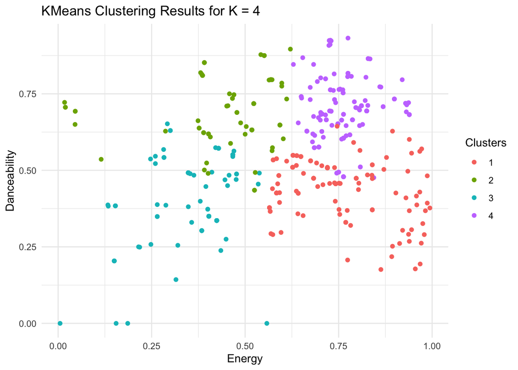

```r
# Add clusters back to original data
X$clusters <- factor(labels)

# Plots

ggplot(X, aes(x = energy, y = danceability, color = clusters)) +
    geom_point() +
    theme_minimal() +
    labs(
      x = "Energy",
      y = "Danceability",
      title = "KMeans Clustering Results for K = 4",
      color = "Clusters"
    )
```

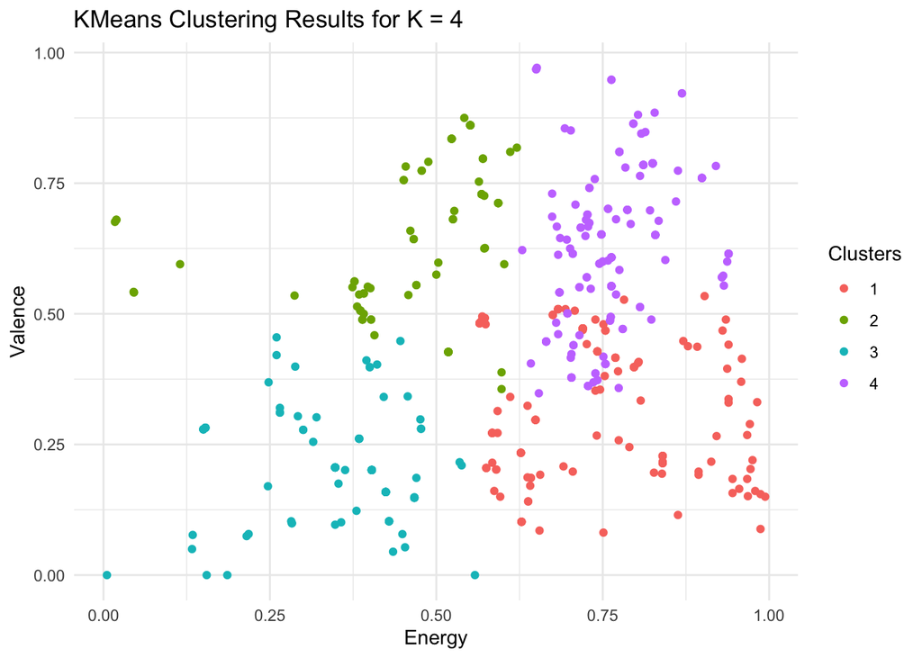

```r
ggplot(X, aes(x = energy, y = valence, color = clusters)) +
    geom_point() +
    theme_minimal() +
    labs(
      x = "Energy",
      y = "Valence",
      title = "KMeans Clustering Results for K = 4",
      color = "Clusters"
    )
```

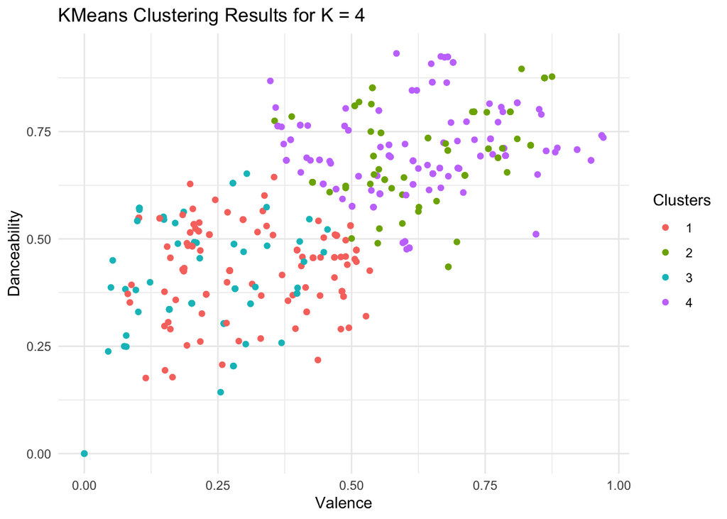

```r
ggplot(X, aes(x = valence, y = danceability, color = clusters)) +
    geom_point() +
    theme_minimal() +
    labs(
      x = "Valence",
      y = "Danceability",
      title = "KMeans Clustering Results for K = 4",
      color = "Clusters"
    )
```

### 1.3.3 Another Example (choosing `k` using the data)

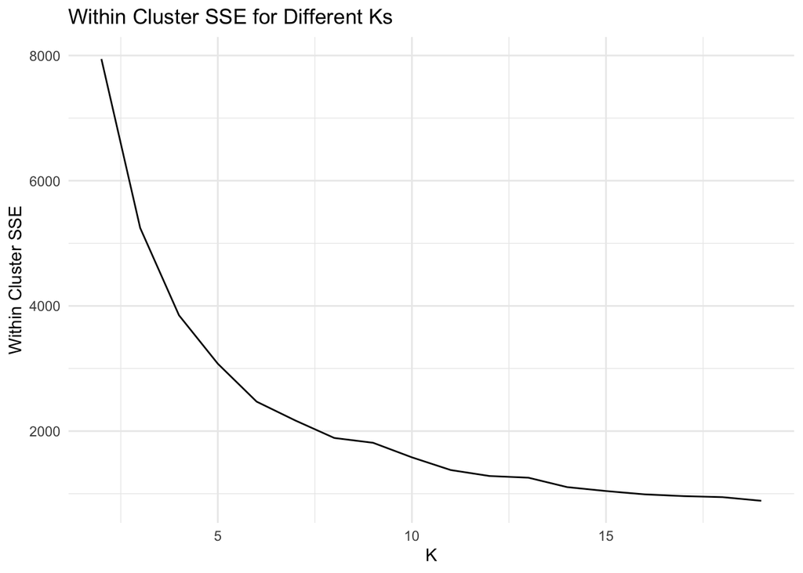

```r
wine <- read.csv(
  "12-data/wineLARGE.csv"
)

# drop rows with NA
wine <- na.omit(wine)

# reset row names (similar to reset_index)
rownames(wine) <- NULL

#### grab data we want to cluster ####
feats <- c("citric.acid", "residual.sugar")

X <- wine[, feats]

#### scale features (StandardScaler equivalent) ####
X_scaled <- scale(X)

#### create empty metrics storage ####
metrics <- data.frame(
  SSE = numeric(),
  sil = numeric(),
  k = integer()
)

#### loop over K ####
set.seed(123)

for (i in 2:19) {
  km <- kmeans(X_scaled, centers = i)

  labels <- km$cluster

  # silhouette score
  sil_vals <- silhouette(labels, dist(X_scaled))
  sil_mean <- mean(sil_vals[, 3])

  # SSE (within-cluster sum of squares)
  sse <- km$tot.withinss

  metrics <- rbind(
    metrics,
    data.frame(SSE = sse, sil = sil_mean, k = i)
  )
}

#### plots ####

ggplot(metrics, aes(x = k, y = SSE)) +
    geom_line() +
    theme_minimal() +
    labs(
      x = "K",
      y = "Within Cluster SSE",
      title = "Within Cluster SSE for Different Ks"
    )
```

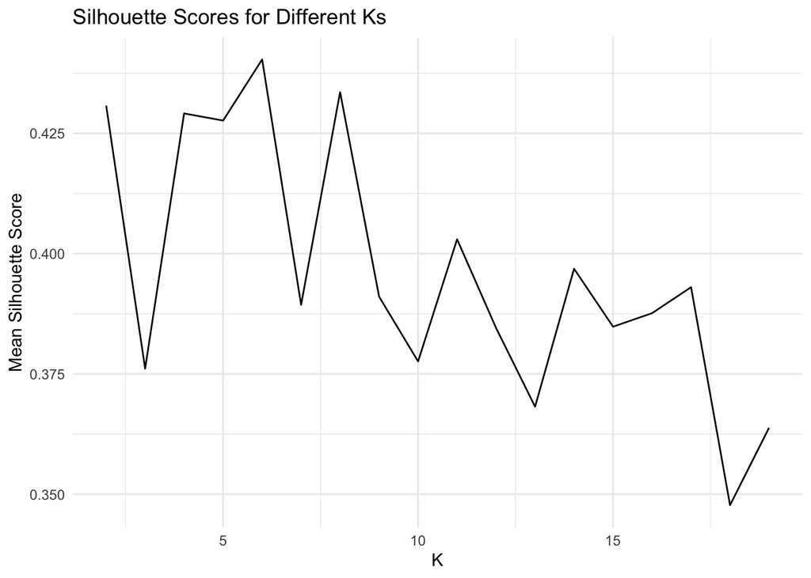

```r
ggplot(metrics, aes(x = k, y = sil)) +
    geom_line() +
    theme_minimal() +
    labs(
      x = "K",
      y = "Mean Silhouette Score",
      title = "Silhouette Scores for Different Ks"
    )
```

The within-cluster SSE plot shows a sharp decrease in error as $K$ increases from 2 to around 5 or 6, indicating that adding clusters in this range substantially improves how well the data are grouped. After $K = 6$, the rate of decrease slows considerably and the curve begins to flatten, suggesting diminishing returns from adding more clusters. This “elbow” around $K = 5–6$ indicates that increasing $K$ beyond this point does not significantly improve cluster compactness, making $K = 6$ a reasonable choice based on the SSE criterion.

The silhouette plot shows that the average silhouette score is highest around $K = 6$, indicating that this value provides the best balance between cluster cohesion and separation. For smaller values of $K$, clusters may be too broad, while for larger values of $K$ the silhouette score generally decreases, suggesting over-clustering. Although there are small fluctuations at other values of $K$, the overall trend supports choosing $K = 6$ as the most appropriate number of clusters for this data.

## 1.4 Hierarchical Clustering

Hierarchical clustering (as the name suggests) assumes that the clusters in the data have a hierarchical relationship.

Hierarchical *Agglomeretive* Clustering (which we perform here), goes bottom up: every datapoint starts as it’s own singleton cluster, and at each step, we merge the two closest clusters together until all data points are in one big cluster. In order to decide which clusters are closest, we need to choose two things:

### 1.4.1 Distance Metrics and Linkage Critera

- **distance metric**: this is a measure that helps us define how close together two *data points* are. Euclidean distance is a common distance metric that you may be familiar with, but there is also cosine distance, manhattan distance, hamming distance, and even custom distance functions (like [levenshtein distance](https://en.wikipedia.org/wiki/Levenshtein_distance) between two strings!)
- **linkage criteria**: this is a measure of how close two *clusters* are. Because (most) clusters have more than one point, we need to define what it means for two clusters to be close.
  - **Single Linkage**: the distance between two clusters (A and B) as the minimum distance between any point in A and any point in B
  - **Average Linkage**: the distance between two clusters (A and B) as the average distance between points in A and points in B.
  - **Complete Linkage**: the distance between two clusters (A and B) as the maximum distance between any point in A and any point in B.
  - **Centroid Method**: the distance between two clusters (A and B) as the distance between their respective mean vectors (centroids).
  - **Ward’s Method** (default): the distance between two clusters (A and B) as the Sum of Squared Errors when combining the two clusters together.
  - and MORE! You could technically define this anyway you wanted.